# Group Part HW3

Daqi Chen, Jacob Warnock, Frederich Ji, Sooho Myoung

9/17/2020

```r
Ames5 <- read.csv("AmesTrain5.csv", header = TRUE, sep = ",")
```

# Part 3: Find a “fancier model”:

```r
model1 = lm(Price~LotFrontage + LotArea + Quality + Condition +
    BasementFinSF + BasementUnFinSF + FirstSF + SecondSF + FullBath +
    HalfBath + Bedroom + Fireplaces + GarageSF + WoodDeckSF +
    OpenPorchSF + EnclosedPorchSF, data = Ames5)

summary(model1)
```

```
##
## Call:
## lm(formula = Price ~ LotFrontage + LotArea + Quality + Condition +
##     BasementFinSF + BasementUnFinSF + FirstSF + SecondSF + FullBath +
##     HalfBath + Bedroom + Fireplaces + GarageSF + WoodDeckSF +
##     OpenPorchSF + EnclosedPorchSF, data = Ames5)
##
## Residuals:
##      Min       1Q   Median       3Q      Max
## -182.133  -16.071   -1.248   14.368  156.460
##
## Coefficients:
##                   Estimate Std. Error t value Pr(>|t|)
## (Intercept)     -1.109e+02  1.012e+01 -10.963  < 2e-16 ***
## LotFrontage      1.723e-01  3.877e-02   4.445 1.05e-05 ***
## LotArea          4.679e-04  9.850e-05   4.750 2.56e-06 ***
## Quality          2.225e+01  1.353e+00  16.441  < 2e-16 ***
## Condition        3.206e+00  1.124e+00   2.852  0.00450 **
## BasementFinSF    3.816e-02  5.028e-03   7.589 1.29e-13 ***
## BasementUnFinSF  1.596e-02  4.987e-03   3.199  0.00145 **
## FirstSF          5.058e-02  6.151e-03   8.224 1.29e-15 ***
## SecondSF         3.734e-02  5.399e-03   6.916 1.22e-11 ***
## FullBath         5.787e+00  3.325e+00   1.740  0.08230 .
## HalfBath         9.146e+00  3.351e+00   2.730  0.00653 **
## Bedroom         -5.455e+00  1.973e+00  -2.764  0.00588 **
## Fireplaces       5.383e+00  2.438e+00   2.208  0.02762 *
## GarageSF         4.623e-02  7.252e-03   6.375 3.72e-10 ***
## WoodDeckSF       2.325e-02  9.901e-03   2.348  0.01920 *
## OpenPorchSF      5.797e-02  1.880e-02   3.084  0.00214 **
## EnclosedPorchSF -3.123e-02  1.999e-02  -1.562  0.11887
## ---
## Signif. codes:  0 '***' 0.001 '**' 0.01 '*' 0.05 '.' 0.1 ' ' 1
##
## Residual standard error: 29.44 on 583 degrees of freedom
## Multiple R-squared:  0.8527, Adjusted R-squared:  0.8486
## F-statistic: 210.9 on 16 and 583 DF,  p-value: < 2.2e-16
```

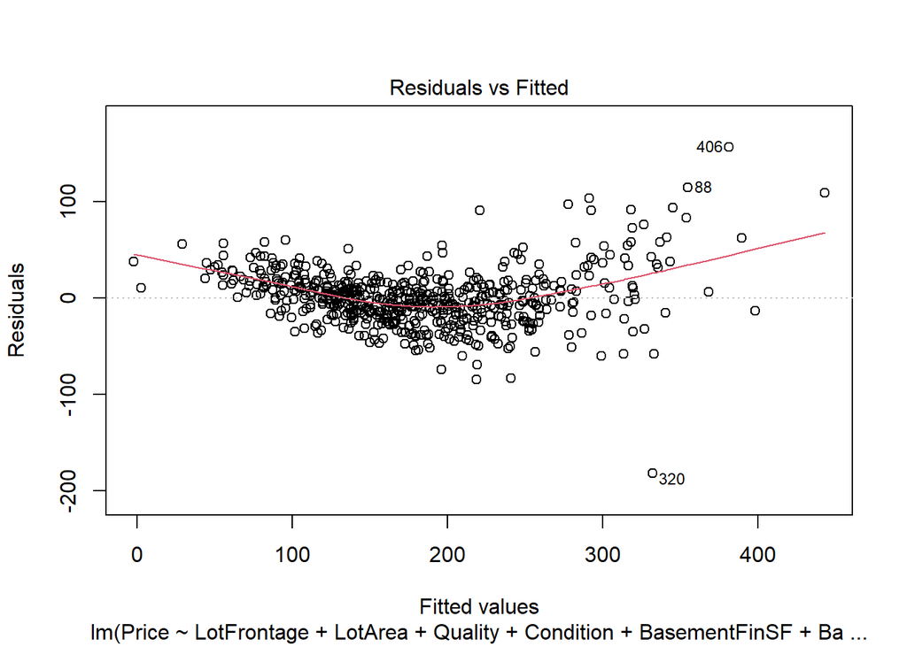

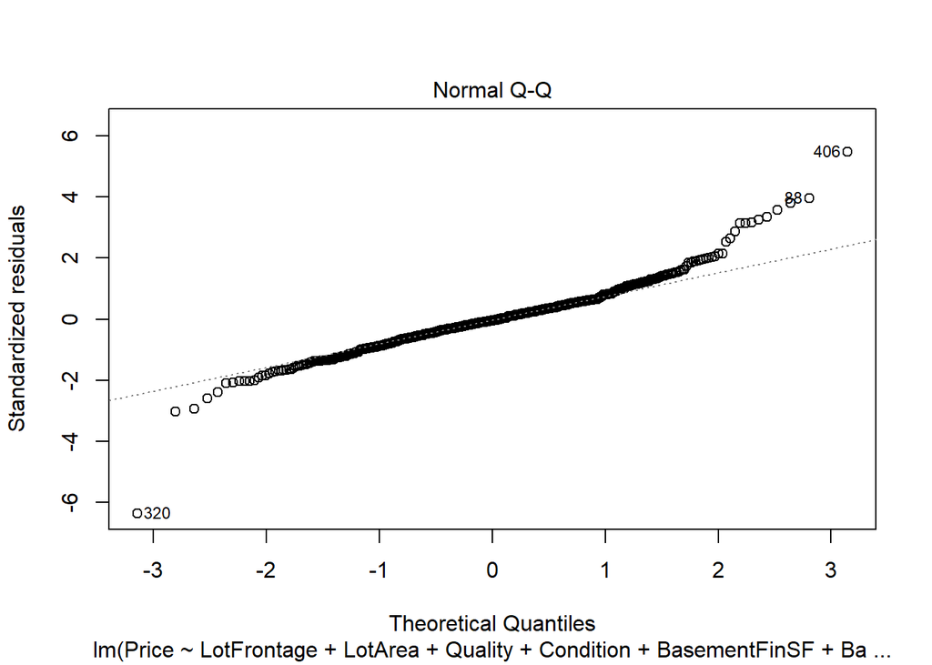

```r
plot(model1, 1:2)
```

## Transformations of predictors

```r
model2 = lm(Price~sqrt(LotFrontage) + sqrt(LotArea) + sqrt(Quality) + sqrt(Condition) +
    BasementFinSF + BasementUnFinSF + FirstSF + SecondSF + FullBath +
    HalfBath + Bedroom + Fireplaces + GarageSF + WoodDeckSF +
    OpenPorchSF + EnclosedPorchSF , data = Ames5)

summary(model2)
```

```
##
## Call:
## lm(formula = Price ~ sqrt(LotFrontage) + sqrt(LotArea) + sqrt(Quality) +
##     sqrt(Condition) + BasementFinSF + BasementUnFinSF + FirstSF +
##     SecondSF + FullBath + HalfBath + Bedroom + Fireplaces + GarageSF +
##     WoodDeckSF + OpenPorchSF + EnclosedPorchSF, data = Ames5)
##
## Residuals:
##      Min       1Q   Median       3Q      Max
## -181.473  -16.583   -2.237   14.387  144.249
##
## Coefficients:
##                     Estimate Std. Error t value Pr(>|t|)
## (Intercept)       -2.485e+02  1.883e+01 -13.197  < 2e-16 ***
## sqrt(LotFrontage)  1.540e+00  3.886e-01   3.964 8.28e-05 ***
## sqrt(LotArea)      2.372e-01  4.466e-02   5.312 1.54e-07 ***
## sqrt(Quality)      9.694e+01  6.594e+00  14.701  < 2e-16 ***
## sqrt(Condition)    1.398e+01  5.495e+00   2.544 0.011204 *
## BasementFinSF      4.027e-02  5.206e-03   7.736 4.53e-14 ***
## BasementUnFinSF    1.869e-02  5.163e-03   3.620 0.000320 ***
## FirstSF            5.153e-02  6.440e-03   8.002 6.64e-15 ***
## SecondSF           3.913e-02  5.570e-03   7.025 5.98e-12 ***
## FullBath           7.091e+00  3.434e+00   2.065 0.039367 *
## HalfBath           9.696e+00  3.460e+00   2.802 0.005241 **
## Bedroom           -7.705e+00  2.037e+00  -3.783 0.000171 ***
## Fireplaces         5.306e+00  2.520e+00   2.106 0.035669 *
## GarageSF           4.954e-02  7.465e-03   6.637 7.32e-11 ***
## WoodDeckSF         2.282e-02  1.024e-02   2.230 0.026159 *
## OpenPorchSF        5.767e-02  1.941e-02   2.971 0.003089 **
## EnclosedPorchSF   -3.309e-02  2.066e-02  -1.602 0.109693
## ---
## Signif. codes:  0 '***' 0.001 '**' 0.01 '*' 0.05 '.' 0.1 ' ' 1
##
## Residual standard error: 30.44 on 583 degrees of freedom
## Multiple R-squared:  0.8425, Adjusted R-squared:  0.8382
## F-statistic:   195 on 16 and 583 DF,  p-value: < 2.2e-16
```

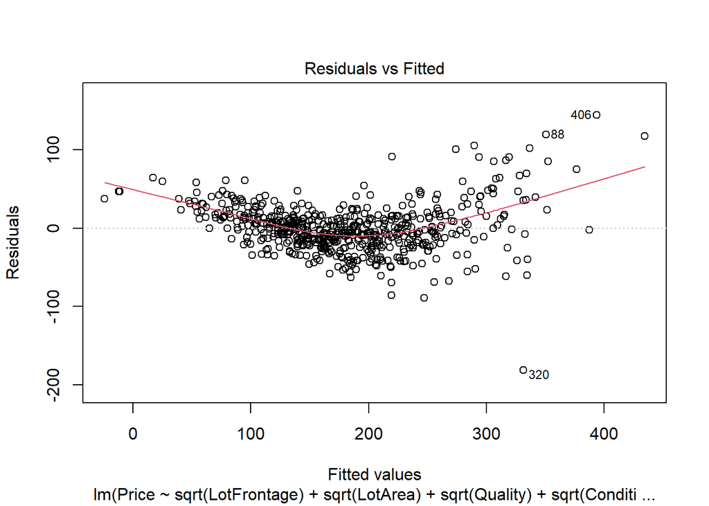

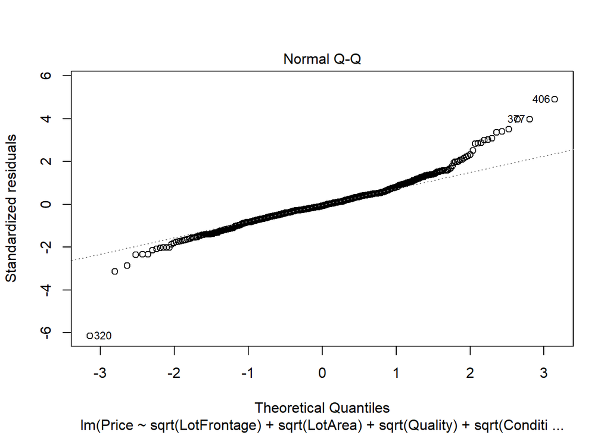

```r
plot(model2, 1:2)
```

- Taking the squareroot of the predictor variables, but adding doesn’t seem to improve the model.

## Transformations of the response

```r
model3 = lm(log(Price)~LotFrontage + LotArea + Quality + Condition +
    BasementFinSF + BasementUnFinSF + FirstSF + SecondSF + FullBath +
    HalfBath + Bedroom + Fireplaces + GarageSF + WoodDeckSF +
    OpenPorchSF + EnclosedPorchSF , data = Ames5)

summary(model3)
```

```
##
## Call:
## lm(formula = log(Price) ~ LotFrontage + LotArea + Quality + Condition +
##     BasementFinSF + BasementUnFinSF + FirstSF + SecondSF + FullBath +
##     HalfBath + Bedroom + Fireplaces + GarageSF + WoodDeckSF +
##     OpenPorchSF + EnclosedPorchSF, data = Ames5)
##
## Residuals:
##      Min       1Q   Median       3Q      Max
## -1.49491 -0.07890  0.01280  0.08662  0.37653
##
## Coefficients:
##                   Estimate Std. Error t value Pr(>|t|)
## (Intercept)      3.382e+00  5.297e-02  63.841  < 2e-16 ***
## LotFrontage      5.446e-04  2.029e-04   2.683 0.007495 **
## LotArea          1.736e-06  5.156e-07   3.367 0.000811 ***
## Quality          1.346e-01  7.084e-03  18.998  < 2e-16 ***
## Condition        3.185e-02  5.883e-03   5.413 9.06e-08 ***
## BasementFinSF    1.802e-04  2.632e-05   6.846 1.93e-11 ***
## BasementUnFinSF  8.795e-05  2.610e-05   3.369 0.000803 ***
## FirstSF          2.051e-04  3.219e-05   6.371 3.81e-10 ***
## SecondSF         1.163e-04  2.826e-05   4.116 4.41e-05 ***
## FullBath         6.009e-02  1.740e-02   3.453 0.000595 ***
## HalfBath         6.355e-02  1.754e-02   3.623 0.000316 ***
## Bedroom          4.447e-03  1.033e-02   0.431 0.666955
## Fireplaces       4.927e-02  1.276e-02   3.861 0.000125 ***
## GarageSF         2.135e-04  3.796e-05   5.625 2.88e-08 ***
## WoodDeckSF       1.305e-04  5.182e-05   2.519 0.012051 *
## OpenPorchSF      3.141e-04  9.840e-05   3.192 0.001487 **
## EnclosedPorchSF -2.070e-04  1.047e-04  -1.978 0.048361 *
## ---
## Signif. codes:  0 '***' 0.001 '**' 0.01 '*' 0.05 '.' 0.1 ' ' 1
##
## Residual standard error: 0.1541 on 583 degrees of freedom
## Multiple R-squared:  0.8602, Adjusted R-squared:  0.8564
## F-statistic: 224.3 on 16 and 583 DF,  p-value: < 2.2e-16
```

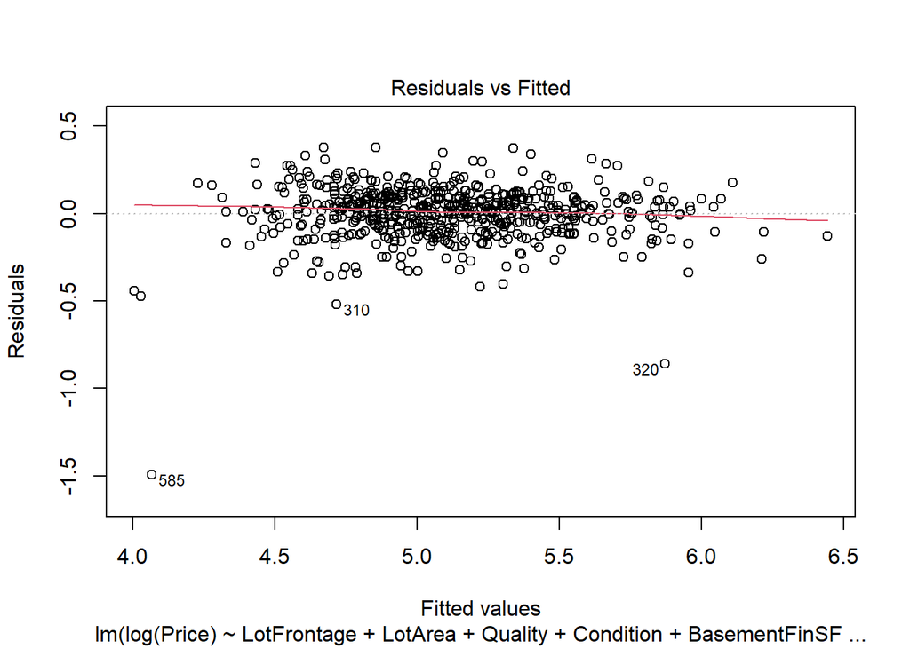

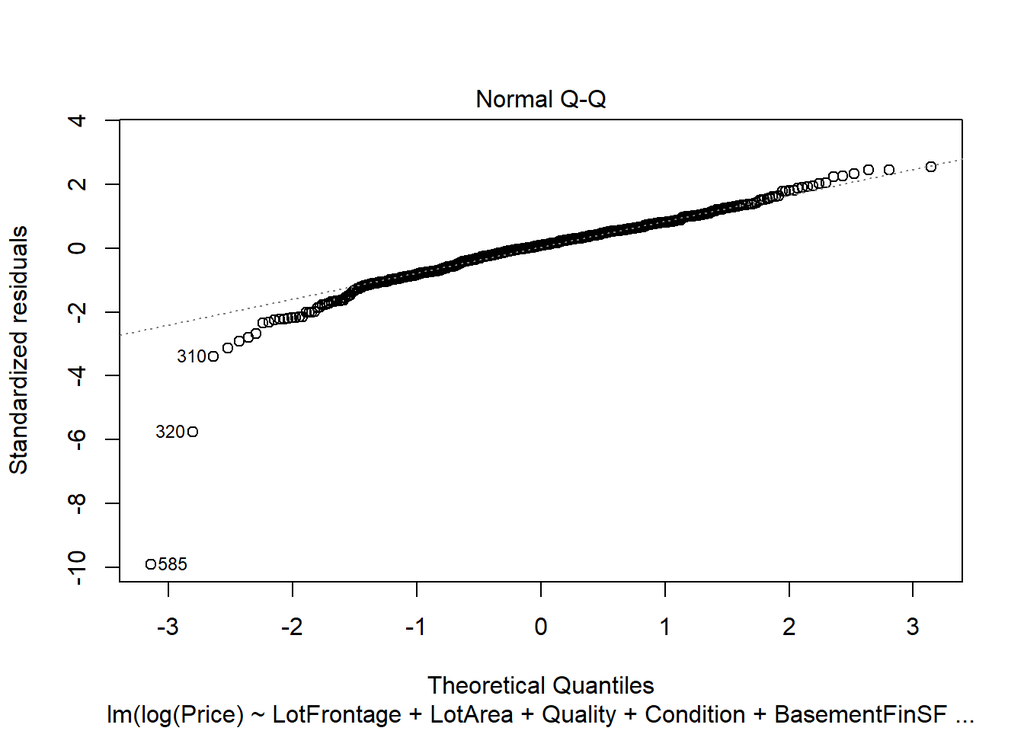

```r
plot(model3, 1:2)
```

- Taking the natural log of the Response variable.

```r
model4 = lm(sqrt(Price)~LotFrontage + LotArea + Quality + Condition +
    BasementFinSF + BasementUnFinSF + FirstSF + SecondSF + FullBath +
    HalfBath + Bedroom + Fireplaces + GarageSF + WoodDeckSF +
    OpenPorchSF + EnclosedPorchSF , data = Ames5)

summary(model4)
```

```
##
## Call:
## lm(formula = sqrt(Price) ~ LotFrontage + LotArea + Quality +
##     Condition + BasementFinSF + BasementUnFinSF + FirstSF + SecondSF +
##     FullBath + HalfBath + Bedroom + Fireplaces + GarageSF + WoodDeckSF +
##     OpenPorchSF + EnclosedPorchSF, data = Ames5)
##
## Residuals:
##     Min      1Q  Median      3Q     Max
## -6.1852 -0.5309  0.0275  0.5159  3.1007
##
## Coefficients:
##                   Estimate Std. Error t value Pr(>|t|)
## (Intercept)      2.285e+00  3.211e-01   7.118 3.24e-12 ***
## LotFrontage      4.988e-03  1.230e-03   4.055 5.70e-05 ***
## LotArea          1.428e-05  3.125e-06   4.570 5.94e-06 ***
## Quality          8.333e-01  4.294e-02  19.406  < 2e-16 ***
## Condition        1.556e-01  3.566e-02   4.363 1.51e-05 ***
## BasementFinSF    1.269e-03  1.595e-04   7.953 9.50e-15 ***
## BasementUnFinSF  5.771e-04  1.582e-04   3.647 0.000289 ***
## FirstSF          1.583e-03  1.952e-04   8.109 3.02e-15 ***
## SecondSF         1.063e-03  1.713e-04   6.204 1.04e-09 ***
## FullBath         3.225e-01  1.055e-01   3.057 0.002337 **
## HalfBath         3.798e-01  1.063e-01   3.572 0.000384 ***
## Bedroom         -9.971e-02  6.261e-02  -1.593 0.111783
## Fireplaces       2.724e-01  7.736e-02   3.522 0.000462 ***
## GarageSF         1.614e-03  2.301e-04   7.013 6.47e-12 ***
## WoodDeckSF       8.309e-04  3.142e-04   2.645 0.008392 **
## OpenPorchSF      2.067e-03  5.965e-04   3.465 0.000570 ***
## EnclosedPorchSF -1.300e-03  6.344e-04  -2.050 0.040842 *
## ---
## Signif. codes:  0 '***' 0.001 '**' 0.01 '*' 0.05 '.' 0.1 ' ' 1
##
## Residual standard error: 0.9342 on 583 degrees of freedom
## Multiple R-squared:  0.8807, Adjusted R-squared:  0.8774
## F-statistic:   269 on 16 and 583 DF,  p-value: < 2.2e-16
```

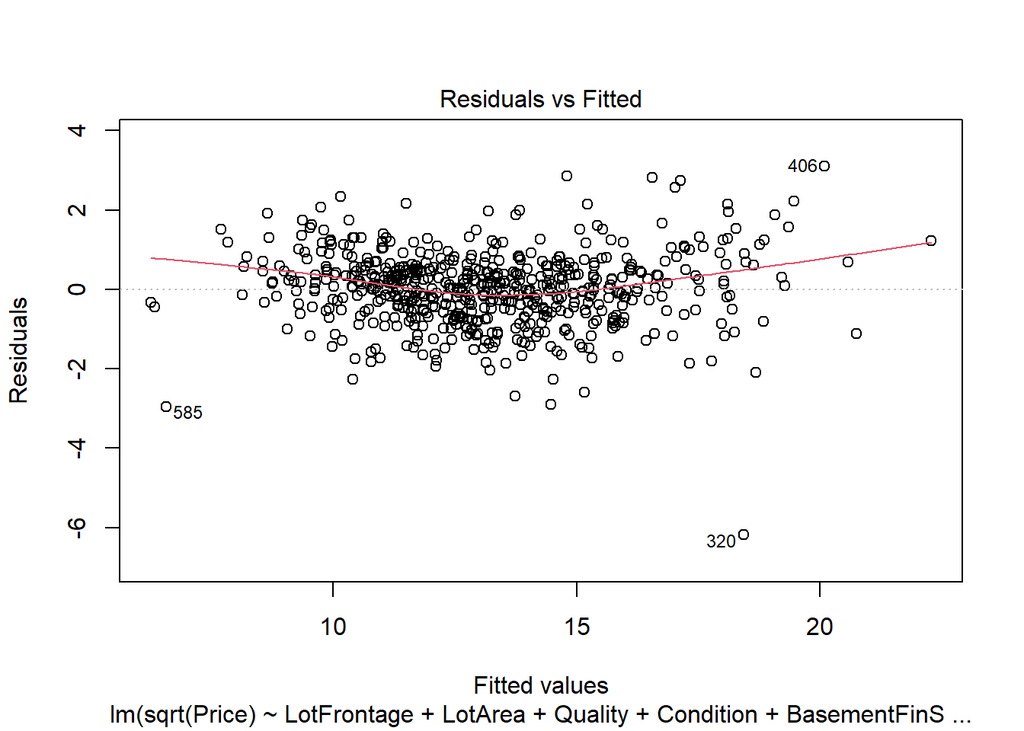

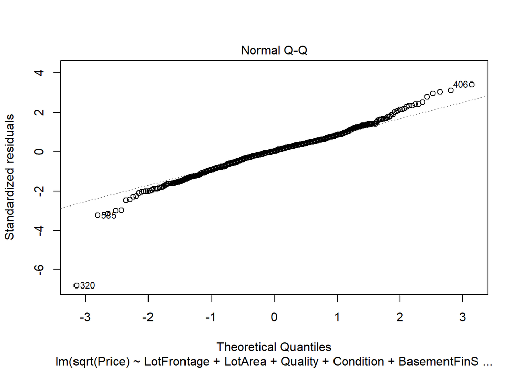

```r
plot(model4, 1:2)
```

# Part 4. Residual analysis for your fancier model - Using Model3

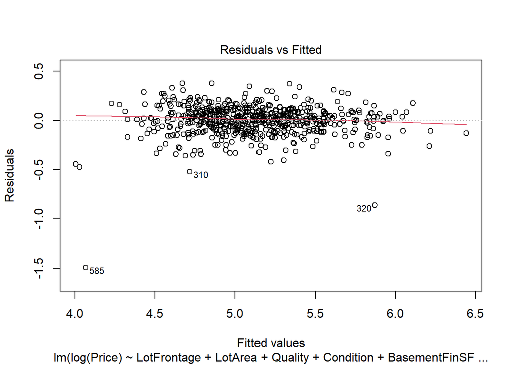

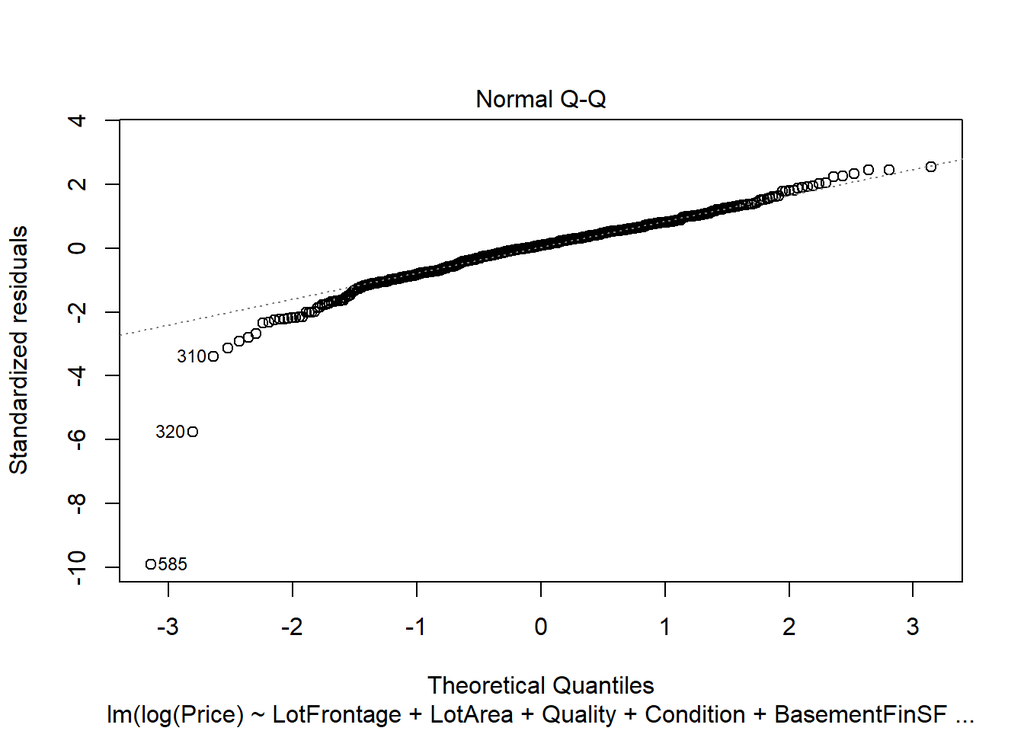

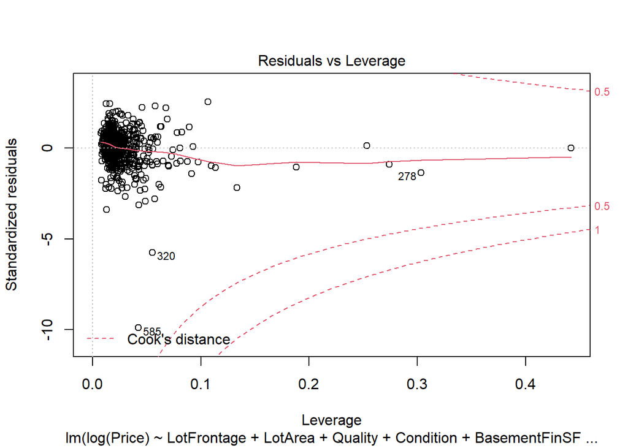

```r
plot(model3, c(1, 2, 5))
```

```r
summary(model3)
```

```
##
## Call:
## lm(formula = log(Price) ~ LotFrontage + LotArea + Quality + Condition +
##     BasementFinSF + BasementUnFinSF + FirstSF + SecondSF + FullBath +
##     HalfBath + Bedroom + Fireplaces + GarageSF + WoodDeckSF +
##     OpenPorchSF + EnclosedPorchSF, data = Ames5)
##
## Residuals:
##      Min       1Q   Median       3Q      Max
## -1.49491 -0.07890  0.01280  0.08662  0.37653
##
## Coefficients:
##                   Estimate Std. Error t value Pr(>|t|)
## (Intercept)      3.382e+00  5.297e-02  63.841  < 2e-16 ***
## LotFrontage      5.446e-04  2.029e-04   2.683 0.007495 **
## LotArea          1.736e-06  5.156e-07   3.367 0.000811 ***
## Quality          1.346e-01  7.084e-03  18.998  < 2e-16 ***
## Condition        3.185e-02  5.883e-03   5.413 9.06e-08 ***
## BasementFinSF    1.802e-04  2.632e-05   6.846 1.93e-11 ***
## BasementUnFinSF  8.795e-05  2.610e-05   3.369 0.000803 ***
## FirstSF          2.051e-04  3.219e-05   6.371 3.81e-10 ***
## SecondSF         1.163e-04  2.826e-05   4.116 4.41e-05 ***
## FullBath         6.009e-02  1.740e-02   3.453 0.000595 ***
## HalfBath         6.355e-02  1.754e-02   3.623 0.000316 ***
## Bedroom          4.447e-03  1.033e-02   0.431 0.666955
## Fireplaces       4.927e-02  1.276e-02   3.861 0.000125 ***
## GarageSF         2.135e-04  3.796e-05   5.625 2.88e-08 ***
## WoodDeckSF       1.305e-04  5.182e-05   2.519 0.012051 *
## OpenPorchSF      3.141e-04  9.840e-05   3.192 0.001487 **
## EnclosedPorchSF -2.070e-04  1.047e-04  -1.978 0.048361 *
## ---
## Signif. codes:  0 '***' 0.001 '**' 0.01 '*' 0.05 '.' 0.1 ' ' 1
##
## Residual standard error: 0.1541 on 583 degrees of freedom
## Multiple R-squared:  0.8602, Adjusted R-squared:  0.8564
## F-statistic: 224.3 on 16 and 583 DF,  p-value: < 2.2e-16
```

### Conditions:

- Linearity:
  - Looking at Residual vs. Fitted plot, the red line is roughly horizontal
  - Met
- Zero Mean:
  - Always Fit by the nature of the model
- Constant Variance:
  - Looking at Residual vs. Fitted plot, no obvious fanning pattern
  - Met
- Normality
  - Looking at qq plot, the data fit this line
  - But left tail has some extreme values below the line, could be problematic
- Independence
  - Looking at Residual vs. Fitted plot, the red line is straight
  - Met